# sc_MOSim wiki

Arianna Febbo

2023-05-12

# 1 Introduction

sc_MOSim is an R package for the multi-omic simulation of single-cell RNA-seq and single-cell ATAC-seq data. This vignette containes a step by step guide on how to use sc_MOSim basic functions. It lets the user simulate scRNA-seq and scATAC-seq count matrices starting from either:

- real count matrix included in the package,
- real count matrix or Seurat object provided by the user.

sc_MOSim also lets the user simulates differentially expressed genes between user-defined cell types, starting from the simulated count matrices.

Finally sc_MOSim simulates the integration between the main omic (scRNA-seq) and the regulatory one (scATAC-seq), by defining regulatory functions (activator, repressor or no effect) of features (or peaks) for the regulatory omic.

# 2 Data preparation

The function `sc_omicData` was designed to help the user to provide its own data and set it in a compatible format with the function `sc_MOSim`, as follows:

`sc_omicData(omics_types, data = NULL)`

`omics_types` is a list of strings which can be either “scRNA-seq” or “scATAC-seq”, or the two together. `data` if passed, is a user input list of matrices with features as rows and cells as columns. Otherwise allows the user to use default data from the package.

## 2.1 Real count matrix uploaded in the package

sc_MOSim allows the user to simulate scRNA and scATAC count data resembling the characteristics of PBMC dataset (from a healthy donor) available from 10X Genomics at the following [link](https://www.10xgenomics.com/resources/datasets/pbmc-from-a-healthy-donor-granulocytes-removed-through-cell-sorting-10-k-1-standard-2-0-0). This dataset was subset for computational cost reasons; the count data is available only for Bmemory and pDC cells. Bmemory cells represent the first 160 cells (columns) of the matrix; pDC cells represent the second 110 cells (columns).

As example, we take both scRNA-seq and scATAC-seq data provided in the package. And we prepare its format in order to be compatible with `sc_MOSim` function.

```r
scOmicData <- sc_omicData(list("scRNA-seq", "scATAC-seq"))
```

`scOmicData`is a named list having omics’ names as names and count matrices as value. It will be one of the argument of function `sc_MOSim`.

## 2.2 Real count matrix or Seurat object provided by the user

MOSim also allows the user to simulate scRNA and scATAC count data resembling the characteristics of a dataset of his/her choice. The supported input formats are :

- count matrix,
- Seurat object.

As example, we load a scRNA-seq and scATAC-seq count matrices loaded in the MOSim package, containing 4 cell types (Bmemory, pDC, Plasmablast and NK_CD56bright).

The count matrices are composed of:

- 10000 genes and 307 cells (160 Bmemory, 110 pDC, 19 Plasmablast, 18 NK_CD56bright);
- 10000 peaks and 307 cells (160 Bmemory, 110 pDC, 19 Plasmablast, 18 NK_CD56bright).

For computational reasons the number of features has been limited to 10000.

```r
rna_counts <- readRDS("../data/RNA_4CellTypes.rds")
atac_counts <- readRDS("../data/ATAC_4CellTypes.rds")

scOmicData_user <- sc_omicData(omics_types = list("scRNA-seq", "scATAC-seq"), data = list(rna_counts,
    atac_counts))
```

`scOmicData_user`is a named list having “scRNA-seq” and “scATAC-seq as names and the example count matrices as values.

# 3 Multi-omic simulation

## 3.1 Without providing optional arguments

MOSim gives the user the opportunity to simulate scRNA and scATAC count matrices which resemble the characteristics of the input data, without providing further arguments, as follows:

`sc_MOSim(omics, cellTypes, numberCells = NULL, mean = NULL, sd = NULL)`

Assuming the data produced in Section 2.2 is being used, scRNAseq and scATACseq count matrices will be simulated, resulting in matrices with the following characteristics:

- 10000 genes and 70 cells;
- 10000 peaks and 70 cells;
- 4 cell types A, B, C and D each matrix;
- cell type A has 20 cells;
- cell type B has 20 cells;
- cell type C has 15 cells;
- cell type D has 15 cells.

`sc_MOSim`, in case of not providing optional arguments, takes as input an omics list and a cell type list.

```r
cell_types <- list(cellA = c(1:20), cellB = c(161:180), cellC = c(271:285), cellD = c(290:304))  #selecting first 20 cells for Bmemory and pDC and the first 15 cells for Plasmablast and NK to perform the simulation

sim <- sc_MOSim(scOmicData_user, cell_types)
```

```
[1] "Experimental condition 1"
[1] "...estimating gene intensity"
[1] "...estimating gene variability"
[1] "...estimating library size"
[1] "...creating SPARSim simulation parameter"
[1] "Experimental condition 2"
[1] "...estimating gene intensity"
[1] "...estimating gene variability"
[1] "...estimating library size"
[1] "...creating SPARSim simulation parameter"
[1] "Experimental condition 3"
[1] "...estimating gene intensity"
[1] "...estimating gene variability"
[1] "...estimating library size"
[1] "...creating SPARSim simulation parameter"
```

[output cut: 39 more lines]

`sim` is a named list having ‘sim_sc + omic name’ as names and Seurat objects as values (where the synthetic count matrices are contained). The simulated count matrices are raw (i.e. not normalized) count tables, having genes on rows and cells on columns, containing read/UMI count values.

```r
sim
```

```
$`sim_scRNA-seq`
An object of class Seurat
10000 features across 70 samples within 1 assay
Active assay: RNA (10000 features, 0 variable features)

$`sim_scATAC-seq`
An object of class Seurat
10000 features across 70 samples within 1 assay
Active assay: ATAC (10000 features, 0 variable features)
```

```r
sim$`sim_scRNA-seq`@assays$RNA@counts[1:5, ]  #printing the first 5 rows of the count matrix for scRNA
```

```
5 x 70 sparse Matrix of class "dgCMatrix"

AL357874.1 . . . . . . . . . . . . . . . . . . . . . . . . . . . . . . . . . .
SNAI2      . . . . . . . . . . . . . . . . . . . . . . . . . . . . . . . . . .
AP002856.3 . . . . . . . . . . . . . . . . . . . . . . . . . . . . . . . . . .
DEFA6      . . . . . . . . . . . . . . . . . . . . . . . . . . . . . . . . . .
GNG13      . . . . . . . . . . . . . . . . . . . . . . . . . . . . . . . . . .

AL357874.1 . . . . . . . . . . . . . . . . . . . . . . . . . . . . . . . . . .
SNAI2      . . . . . . . . . . . . . . . . . . . . . . . . . . . . . . . . . .
AP002856.3 . . . . . . . . . . . . . . . . . . . . . . . . . . . . . . . . . .
DEFA6      . . . . . . . . . . . . . . . . . . . . . . . . . . . . . . . . . .
GNG13      . . . . . . . . . . . . . . . . . . . . . . . . . . . . . . . . . .

AL357874.1 . .
SNAI2      . .
AP002856.3 . .
DEFA6      . .
GNG13      . .
```

```r
sim$`sim_scATAC-seq`@assays$ATAC@counts[1:5, ]  #printing the first 5 rows of the count matrix for scATAC
```

```
5 x 70 sparse Matrix of class "dgCMatrix"

chr9-78695600-78696030   . . . . . . . . . . . . . . . . . . . . . . . . . . .
chrX-71095489-71096362   . . 3 . 1 . . . 1 . . . 1 . . . 4 . . 4 1 3 . . 1 . 1
chr7-142104572-142105486 . . . . 1 . . . . . . . 1 . . . . . . . . . . . . . .
chr21-46488990-46489825  . . . . . . . . . . . . . . . . . . . . . . . . . . 1
chr12-31500824-31501711  . . . . . . 1 . . . . . 1 . . . . . . . . . . . . . .

chr9-78695600-78696030   . . . . . . . . . . . . . . . . . . . . . . . . . . .
chrX-71095489-71096362   . . . . 2 . 1 . . . . . . . 2 . . . . 2 . 1 5 2 . . 1
chr7-142104572-142105486 . . . . . . . . . . . . . . . . . . . . . . . . . . .
chr21-46488990-46489825  . . . . . . . . 1 . . . . . . . . . . . . . . . . . .
chr12-31500824-31501711  . . . . . . . . . . . . . . . . . . . . . . . . . . .

chr9-78695600-78696030   . . . . . . . . . . . . . . . .
chrX-71095489-71096362   4 . . . . 2 2 . . 1 . 1 4 2 . .
chr7-142104572-142105486 . . . . . . . . . . . . . . . .
chr21-46488990-46489825  . . . . . . . . . . . . . . . .
chr12-31500824-31501711  . . . . . . . . . . . . . . . .
```

Let’s visualize first the elbow plot for scRNA-seq and then use UMAP, a non linear dimensional reduction, to place similar cells together in low-dimensional space.

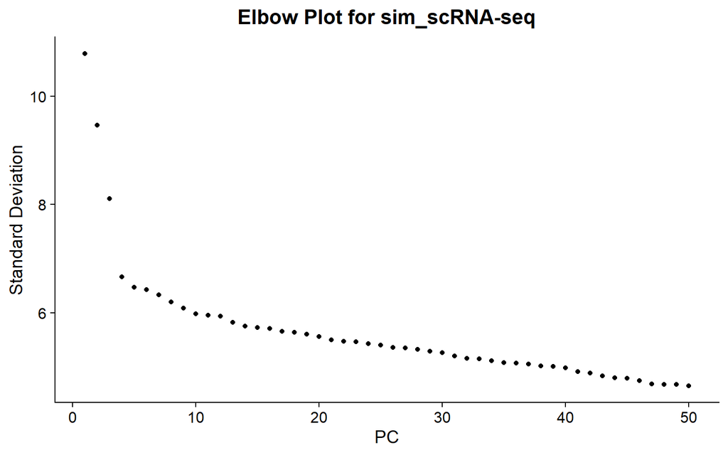

```r
scRNA_pca <- NormalizeData(object = sim[["sim_scRNA-seq"]], normalization.method = "LogNormalize",
    scale.factor = 10000)

scRNA_pca <- FindVariableFeatures(scRNA_pca, selection.method = "vst", nfeatures = 2000)


scRNA_pca <- ScaleData(scRNA_pca, features = rownames(scRNA_pca))

scRNA_pca <- RunPCA(scRNA_pca, features = VariableFeatures(object = scRNA_pca))
ElbowPlot(scRNA_pca, ndims = 50) + ggtitle("Elbow Plot for sim_scRNA-seq") + theme(plot.title = element_text(hjust = 0.5))
```

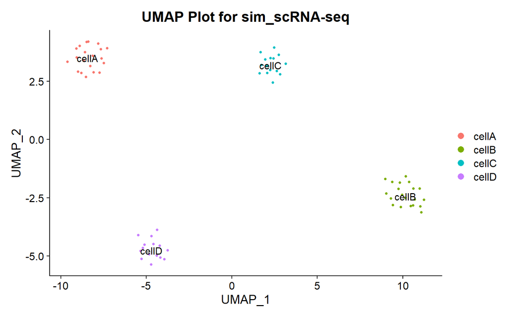

```r
scRNA_pca <- RunUMAP(scRNA_pca, dims = 1:10)

DimPlot(scRNA_pca, reduction = "umap", label = TRUE) + ggtitle("UMAP Plot for sim_scRNA-seq") +
    theme(plot.title = element_text(hjust = 0.5))
```

Let’s do the same thing for the simulated scATAC-seq.

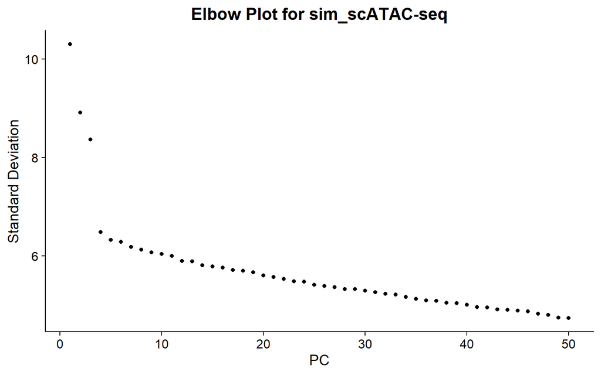

```r
scATAC_pca <- NormalizeData(object = sim[["sim_scATAC-seq"]], normalization.method = "LogNormalize",
    scale.factor = 10000)

scATAC_pca <- FindVariableFeatures(scATAC_pca, selection.method = "vst", nfeatures = 2000)


scATAC_pca <- ScaleData(scATAC_pca, features = rownames(scATAC_pca))

scATAC_pca <- RunPCA(scATAC_pca, features = VariableFeatures(object = scATAC_pca))
ElbowPlot(scATAC_pca, ndims = 50) + ggtitle("Elbow Plot for sim_scATAC-seq") + theme(plot.title = element_text(hjust = 0.5))
```

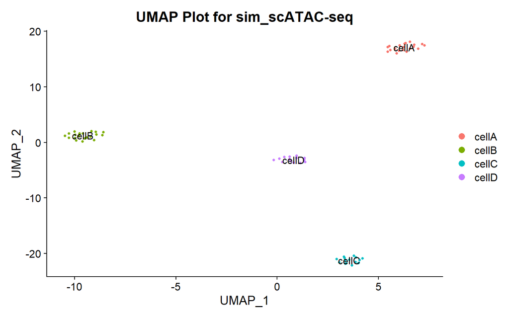

```r
scATAC_pca <- RunUMAP(scATAC_pca, dims = 1:10)

DimPlot(scATAC_pca, reduction = "umap", label = TRUE) + ggtitle("UMAP Plot for sim_scATAC-seq") +
    theme(plot.title = element_text(hjust = 0.5))
```

## 3.2 Providing optional arguments

In case the user wants to simulate a custom amount of cells per cell type and provide mean and standard deviation for the library size (cell library size), there’s the possibility to pass those arguments to `sc_MOSim`. The result count matrices will have:

- 10000 genes and 80 cells;
- 10000 peaks and 80 cells;
- 4 cell types A, B, C and D each matrix;
- cell type A has 10 cells, with an average library size of 2M reads and sd of 500K;
- cell type B has 30 cells, with an average library size of 1M reads and sd of 200k;
- cell type C has 10 cells, with an average library size of 2M reads and sd of 500K;
- cell type D has 30 cells, with an average library size of 1M reads and sd of 200k.

```r
cell_types <- list(cellA = c(1:20), cellB = c(161:180), cellC = c(271:285), cellD = c(290:304))
sim_with_arg <- sc_MOSim(scOmicData_user, cell_types, numberCells = c(10, 30, 10,
    30), mean = c(2 * 10^6, 1 * 10^6, 2 * 10^6, 1 * 10^6), sd = c(5 * 10^5, 2 * 10^5,
    5 * 10^5, 2 * 10^5))
```

```
[1] "Experimental condition 1"
[1] "...estimating gene intensity"
[1] "...estimating gene variability"
[1] "...estimating library size"
[1] "...creating SPARSim simulation parameter"
[1] "Experimental condition 2"
[1] "...estimating gene intensity"
[1] "...estimating gene variability"
[1] "...estimating library size"
[1] "...creating SPARSim simulation parameter"
[1] "Experimental condition 3"
[1] "...estimating gene intensity"
[1] "...estimating gene variability"
[1] "...estimating library size"
[1] "...creating SPARSim simulation parameter"
```

[output cut: 39 more lines]

`sim_with_arg` is a named list having ‘sim_sc + omic name’ as names and Seurat objects as values (where the synthetic count matrices are contained).

# 4 Multi-omic integration

## 4.1 Without providing optional arguments

MOSim can also define the regulatory function (activator, repressor, or no effect) of features in the regulatory omics data, i.e. the peaks in scATAC-seq, without providing the optional arguments. It’s mandatory that the simulation would include both the central data type and the regulatory one. The single-cell multi-omic integration, goes as follows:

`sc_integration <- sc_omicSim(sim, cellTypes, totalFeatures = NULL, regulatorEffect = NULL, associationList = NULL)`

```
[1] "the length of cellTypes is 4"
```

`sc_integration` is a named list reporting the markers and their regulatory functions between every couple of cell types. Peak_id, activity and cell type is the data reported in the list.

```r
sc_integration[["markers_cellA_cellB"]][1061:1090, ]
```

```
                       peak_id  activity cell_type
1061 chr11-102924736-102925645        NE        NA
1062 chr11-102914420-102915279        NE        NA
1063   chr11-96197570-96198473 repressor     cellA
1064   chr11-96197570-96198473 repressor     cellB
1065   chr11-96126758-96127592        NE        NA
1066   chr11-96123010-96123813        NE        NA
1067    chr7-36126246-36126756        NE        NA
1068 chr11-129327431-129328336        NE        NA
1069    chr1-93111437-93112250        NE        NA
1070 chr11-124762915-124763772        NE        NA
1071 chr11-124670500-124671402        NE        NA
1072 chr11-124668850-124669748        NE        NA
1073 chr11-122981464-122982300        NE        NA
1074 chr11-119134153-119135059        NE        NA
```

[output cut: 16 more lines]

## 4.2 Providing optional arguments

[output not shown]

`sc_integration_with_arg` is a named list reporting the markers and their regulatory functions between every couple of cell types. Peak_id, activity and cell type is the data reported in the list. The markers and their regulatory functions between every pair of cell types were identified using a subset of 1,000 features, which is smaller than the 10,000 features used in `sc_integration`. Among these features, those with ‘activator’ function were reduced to 80%, while those with ‘repressor’ or ‘no effect’ function were reduced to 10% each.

```r
sc_integration_with_arg[["markers_cellA_cellB_subset"]][1:20, ]
```

```
                     peak_id  activity cell_type
862   chr9-37422165-37423078 activator     cellA
239   chr5-43313147-43314025 activator     cellB
420   chr6-33279696-33280491 activator     cellB
160  chr12-56138599-56139459 activator     cellB
172   chr6-24666488-24667379 activator     cellA
978  chr16-25093124-25094010 activator     cellB
872   chr9-14692875-14693811 activator     cellA
206   chr6-17583978-17584896 activator     cellB
432    chr19-5622465-5623394 activator     cellA
890   chr9-21802527-21803421 activator     cellB
358  chr12-48197830-48198721 activator     cellA
406   chr6-33668662-33669549 activator     cellA
742    chr20-5100497-5101388 repressor     cellA
1063 chr11-96197570-96198473 repressor     cellA
863   chr9-37422165-37423078 repressor     cellB
339  chr22-36902374-36903197        NE        NA
37     chr17-8059968-8060861        NE        NA
1169 chr19-12793334-12794222        NE        NA
748      chr20-259729-260477        NE        NA
907   chr1-32426964-32427480        NE        NA
```